# Risk Factor Analysis

## Outcome Variable

**Outcome Variable:** whz

## Predictor Variables

**Intervention Variable:** predfeed6

**Adjustment Set:**

- arm
- sex
- month
- brthmon
- W_mage
- meducyrs
- feducyrs
- hhwealth_quart
- hfoodsec
- W_mhtcm
- W_mwtkg
- W_mbmi
- vagbrth
- W_gagebrth
- W_birthwt
- W_birthlen
- W_nrooms
- W_nchldlt5
- W_parity
- impfloor
- impsan
- safeh20
- delta_W_mage
- delta_meducyrs
- delta_feducyrs
- delta_hhwealth_quart
- delta_hfoodsec
- delta_W_mhtcm
- delta_W_mwtkg
- delta_W_mbmi
- delta_vagbrth
- delta_W_gagebrth
- delta_W_birthwt
- delta_W_birthlen
- delta_W_nrooms
- delta_W_nchldlt5
- delta_W_parity
- delta_impfloor
- delta_impsan
- delta_safeh20

## Stratifying Variables

The analysis was stratified on these variable(s):

- agecat
- studyid
- country

## Data Summary

| agecat | studyid | country | predfeed6 | n_cell | n |
| --- | --- | --- | --- | --- | --- |
| Birth | ki0047075b-MAL-ED | BANGLADESH | 1 | 68 | 194 |
| Birth | ki0047075b-MAL-ED | BANGLADESH | 0 | 126 | 194 |
| Birth | ki0047075b-MAL-ED | BRAZIL | 1 | 5 | 57 |
| Birth | ki0047075b-MAL-ED | BRAZIL | 0 | 52 | 57 |
| Birth | ki0047075b-MAL-ED | INDIA | 1 | 4 | 37 |
| Birth | ki0047075b-MAL-ED | INDIA | 0 | 33 | 37 |
| Birth | ki0047075b-MAL-ED | NEPAL | 1 | 3 | 23 |
| Birth | ki0047075b-MAL-ED | NEPAL | 0 | 20 | 23 |
| Birth | ki0047075b-MAL-ED | PERU | 1 | 72 | 208 |
| Birth | ki0047075b-MAL-ED | PERU | 0 | 136 | 208 |
| Birth | ki0047075b-MAL-ED | SOUTH AFRICA | 1 | 1 | 90 |
| Birth | ki0047075b-MAL-ED | SOUTH AFRICA | 0 | 89 | 90 |
| Birth | ki0047075b-MAL-ED | TANZANIA, UNITED REPUBLIC OF | 1 | 0 | 105 |
| Birth | ki0047075b-MAL-ED | TANZANIA, UNITED REPUBLIC OF | 0 | 105 | 105 |
| Birth | ki1000109-EE | PAKISTAN | 1 | 24 | 28 |
| Birth | ki1000109-EE | PAKISTAN | 0 | 4 | 28 |
| Birth | ki1113344-GMS-Nepal | NEPAL | 1 | 390 | 522 |
| Birth | ki1113344-GMS-Nepal | NEPAL | 0 | 132 | 522 |
| Birth | kiGH5241-JiVitA-3 | BANGLADESH | 1 | 8392 | 10744 |
| Birth | kiGH5241-JiVitA-3 | BANGLADESH | 0 | 2352 | 10744 |
| Birth | kiGH5241-JiVitA-4 | BANGLADESH | 1 | 1802 | 2224 |
| Birth | kiGH5241-JiVitA-4 | BANGLADESH | 0 | 422 | 2224 |
| 6 months | ki0047075b-MAL-ED | BANGLADESH | 1 | 84 | 231 |
| 6 months | ki0047075b-MAL-ED | BANGLADESH | 0 | 147 | 231 |
| 6 months | ki0047075b-MAL-ED | BRAZIL | 1 | 30 | 209 |
| 6 months | ki0047075b-MAL-ED | BRAZIL | 0 | 179 | 209 |
| 6 months | ki0047075b-MAL-ED | INDIA | 1 | 11 | 218 |
| 6 months | ki0047075b-MAL-ED | INDIA | 0 | 207 | 218 |
| 6 months | ki0047075b-MAL-ED | NEPAL | 1 | 12 | 225 |
| 6 months | ki0047075b-MAL-ED | NEPAL | 0 | 213 | 225 |
| 6 months | ki0047075b-MAL-ED | PERU | 1 | 92 | 271 |
| 6 months | ki0047075b-MAL-ED | PERU | 0 | 179 | 271 |
| 6 months | ki0047075b-MAL-ED | SOUTH AFRICA | 1 | 3 | 233 |
| 6 months | ki0047075b-MAL-ED | SOUTH AFRICA | 0 | 230 | 233 |
| 6 months | ki0047075b-MAL-ED | TANZANIA, UNITED REPUBLIC OF | 1 | 1 | 232 |
| 6 months | ki0047075b-MAL-ED | TANZANIA, UNITED REPUBLIC OF | 0 | 231 | 232 |
| 6 months | ki1000109-EE | PAKISTAN | 1 | 43 | 48 |
| 6 months | ki1000109-EE | PAKISTAN | 0 | 5 | 48 |
| 6 months | ki1000304b-SAS-FoodSuppl | INDIA | 1 | 0 | 168 |
| 6 months | ki1000304b-SAS-FoodSuppl | INDIA | 0 | 168 | 168 |
| 6 months | ki1113344-GMS-Nepal | NEPAL | 1 | 406 | 547 |
| 6 months | ki1113344-GMS-Nepal | NEPAL | 0 | 141 | 547 |
| 6 months | ki1148112-LCNI-5 | MALAWI | 1 | 47 | 272 |
| 6 months | ki1148112-LCNI-5 | MALAWI | 0 | 225 | 272 |
| 6 months | kiGH5241-JiVitA-3 | BANGLADESH | 1 | 7625 | 9882 |
| 6 months | kiGH5241-JiVitA-3 | BANGLADESH | 0 | 2257 | 9882 |
| 6 months | kiGH5241-JiVitA-4 | BANGLADESH | 1 | 3327 | 4275 |
| 6 months | kiGH5241-JiVitA-4 | BANGLADESH | 0 | 948 | 4275 |
| 24 months | ki0047075b-MAL-ED | BANGLADESH | 1 | 76 | 205 |
| 24 months | ki0047075b-MAL-ED | BANGLADESH | 0 | 129 | 205 |
| 24 months | ki0047075b-MAL-ED | BRAZIL | 1 | 25 | 169 |
| 24 months | ki0047075b-MAL-ED | BRAZIL | 0 | 144 | 169 |
| 24 months | ki0047075b-MAL-ED | INDIA | 1 | 11 | 209 |
| 24 months | ki0047075b-MAL-ED | INDIA | 0 | 198 | 209 |
| 24 months | ki0047075b-MAL-ED | NEPAL | 1 | 12 | 219 |
| 24 months | ki0047075b-MAL-ED | NEPAL | 0 | 207 | 219 |
| 24 months | ki0047075b-MAL-ED | PERU | 1 | 68 | 201 |
| 24 months | ki0047075b-MAL-ED | PERU | 0 | 133 | 201 |
| 24 months | ki0047075b-MAL-ED | SOUTH AFRICA | 1 | 3 | 216 |
| 24 months | ki0047075b-MAL-ED | SOUTH AFRICA | 0 | 213 | 216 |
| 24 months | ki0047075b-MAL-ED | TANZANIA, UNITED REPUBLIC OF | 1 | 1 | 202 |
| 24 months | ki0047075b-MAL-ED | TANZANIA, UNITED REPUBLIC OF | 0 | 201 | 202 |
| 24 months | ki1000109-EE | PAKISTAN | 1 | 20 | 23 |
| 24 months | ki1000109-EE | PAKISTAN | 0 | 3 | 23 |
| 24 months | ki1113344-GMS-Nepal | NEPAL | 1 | 355 | 469 |
| 24 months | ki1113344-GMS-Nepal | NEPAL | 0 | 114 | 469 |
| 24 months | ki1148112-LCNI-5 | MALAWI | 1 | 34 | 184 |
| 24 months | ki1148112-LCNI-5 | MALAWI | 0 | 150 | 184 |
| 24 months | kiGH5241-JiVitA-3 | BANGLADESH | 1 | 3909 | 5067 |
| 24 months | kiGH5241-JiVitA-3 | BANGLADESH | 0 | 1158 | 5067 |
| 24 months | kiGH5241-JiVitA-4 | BANGLADESH | 1 | 3278 | 4184 |
| 24 months | kiGH5241-JiVitA-4 | BANGLADESH | 0 | 906 | 4184 |

The following strata were considered:

- agecat: 24 months, studyid: ki0047075b-MAL-ED, country: BANGLADESH
- agecat: 24 months, studyid: ki0047075b-MAL-ED, country: BRAZIL
- agecat: 24 months, studyid: ki0047075b-MAL-ED, country: INDIA
- agecat: 24 months, studyid: ki0047075b-MAL-ED, country: NEPAL
- agecat: 24 months, studyid: ki0047075b-MAL-ED, country: PERU
- agecat: 24 months, studyid: ki0047075b-MAL-ED, country: SOUTH AFRICA
- agecat: 24 months, studyid: ki0047075b-MAL-ED, country: TANZANIA, UNITED REPUBLIC OF
- agecat: 24 months, studyid: ki1000109-EE, country: PAKISTAN
- agecat: 24 months, studyid: ki1113344-GMS-Nepal, country: NEPAL
- agecat: 24 months, studyid: ki1148112-LCNI-5, country: MALAWI
- agecat: 24 months, studyid: kiGH5241-JiVitA-3, country: BANGLADESH
- agecat: 24 months, studyid: kiGH5241-JiVitA-4, country: BANGLADESH
- agecat: 6 months, studyid: ki0047075b-MAL-ED, country: BANGLADESH
- agecat: 6 months, studyid: ki0047075b-MAL-ED, country: BRAZIL
- agecat: 6 months, studyid: ki0047075b-MAL-ED, country: INDIA
- agecat: 6 months, studyid: ki0047075b-MAL-ED, country: NEPAL
- agecat: 6 months, studyid: ki0047075b-MAL-ED, country: PERU
- agecat: 6 months, studyid: ki0047075b-MAL-ED, country: SOUTH AFRICA
- agecat: 6 months, studyid: ki0047075b-MAL-ED, country: TANZANIA, UNITED REPUBLIC OF
- agecat: 6 months, studyid: ki1000109-EE, country: PAKISTAN
- agecat: 6 months, studyid: ki1000304b-SAS-FoodSuppl, country: INDIA
- agecat: 6 months, studyid: ki1113344-GMS-Nepal, country: NEPAL
- agecat: 6 months, studyid: ki1148112-LCNI-5, country: MALAWI
- agecat: 6 months, studyid: kiGH5241-JiVitA-3, country: BANGLADESH
- agecat: 6 months, studyid: kiGH5241-JiVitA-4, country: BANGLADESH
- agecat: Birth, studyid: ki0047075b-MAL-ED, country: BANGLADESH
- agecat: Birth, studyid: ki0047075b-MAL-ED, country: BRAZIL
- agecat: Birth, studyid: ki0047075b-MAL-ED, country: INDIA
- agecat: Birth, studyid: ki0047075b-MAL-ED, country: NEPAL
- agecat: Birth, studyid: ki0047075b-MAL-ED, country: PERU
- agecat: Birth, studyid: ki0047075b-MAL-ED, country: SOUTH AFRICA
- agecat: Birth, studyid: ki0047075b-MAL-ED, country: TANZANIA, UNITED REPUBLIC OF
- agecat: Birth, studyid: ki1000109-EE, country: PAKISTAN
- agecat: Birth, studyid: ki1113344-GMS-Nepal, country: NEPAL
- agecat: Birth, studyid: kiGH5241-JiVitA-3, country: BANGLADESH
- agecat: Birth, studyid: kiGH5241-JiVitA-4, country: BANGLADESH

### Dropped Strata

Some strata were dropped due to rare outcomes:

- agecat: Birth, studyid: ki0047075b-MAL-ED, country: INDIA
- agecat: Birth, studyid: ki0047075b-MAL-ED, country: NEPAL
- agecat: Birth, studyid: ki0047075b-MAL-ED, country: SOUTH AFRICA
- agecat: Birth, studyid: ki0047075b-MAL-ED, country: TANZANIA, UNITED REPUBLIC OF
- agecat: Birth, studyid: ki1000109-EE, country: PAKISTAN
- agecat: 6 months, studyid: ki0047075b-MAL-ED, country: SOUTH AFRICA
- agecat: 6 months, studyid: ki0047075b-MAL-ED, country: TANZANIA, UNITED REPUBLIC OF
- agecat: 6 months, studyid: ki1000304b-SAS-FoodSuppl, country: INDIA
- agecat: 24 months, studyid: ki0047075b-MAL-ED, country: SOUTH AFRICA
- agecat: 24 months, studyid: ki0047075b-MAL-ED, country: TANZANIA, UNITED REPUBLIC OF
- agecat: 24 months, studyid: ki1000109-EE, country: PAKISTAN

## Methods Detail

We’re interested in the causal parameters $E[Y_a]$ for all values of $a \in \mathcal{A}$. These parameters represent the mean outcome if, possibly contrary to fact, we intervened to set all units to have $A=a$. Under the randomization and positivity assumptions, these are identified by the statistical parameters $\psi_a=E_W[E_{Y|A,W}(Y|A=a,W)]$. In addition, we’re interested in the mean of $Y$, $E[Y]$ under no intervention (the observed mean). We will estimate these parameters by using SuperLearner to fit the relevant likelihood factors – $E_{Y|A,W}(Y|A=a,W)$ and $p(A=a|W)$, and then updating our likelihood fit using a joint TMLE.

For unadjusted analyses ($W=\{\}$), initial likelihoods were estimated using Lrnr_glm to estimate the simple $E(Y|A)$ and Lrnr_mean to estimate $p(A)$. For adjusted analyses, a small library containing Lrnr_glmnet, Lrnr_xgboost, and Lrnr_mean was used.

Having estimated these parameters, we will then use the delta method to estimate relative risks and attributable risks relative to a prespecified baseline level of $A$.

# Results Detail

## Results Plots

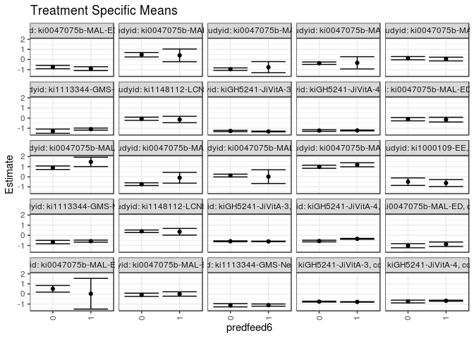

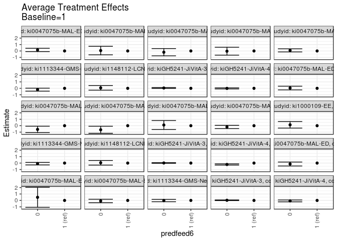

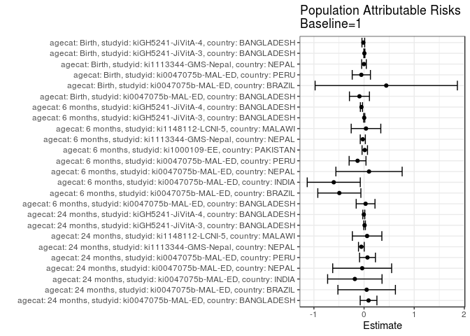

## Results Table

### Parameter: TSM

| agecat | studyid | country | intervention_level | baseline_level | estimate | ci_lower | ci_upper |
| --- | --- | --- | --- | --- | --- | --- | --- |
| Birth | ki0047075b-MAL-ED | BANGLADESH | 1 | NA | -0.8833368 | -1.1074446 | -0.6592290 |
| Birth | ki0047075b-MAL-ED | BANGLADESH | 0 | NA | -1.0283066 | -1.2334423 | -0.8231709 |
| Birth | ki0047075b-MAL-ED | BRAZIL | 1 | NA | 0.0220000 | -1.4978207 | 1.5418207 |
| Birth | ki0047075b-MAL-ED | BRAZIL | 0 | NA | 0.5069231 | 0.1803892 | 0.8334570 |
| Birth | ki0047075b-MAL-ED | PERU | 1 | NA | -0.0041235 | -0.2219429 | 0.2136959 |
| Birth | ki0047075b-MAL-ED | PERU | 0 | NA | -0.0857283 | -0.2473291 | 0.0758724 |
| Birth | ki1113344-GMS-Nepal | NEPAL | 1 | NA | -1.1046899 | -1.2171228 | -0.9922570 |
| Birth | ki1113344-GMS-Nepal | NEPAL | 0 | NA | -1.1227297 | -1.2810796 | -0.9643799 |
| Birth | kiGH5241-JiVitA-3 | BANGLADESH | 1 | NA | -0.7870934 | -0.8118685 | -0.7623183 |
| Birth | kiGH5241-JiVitA-3 | BANGLADESH | 0 | NA | -0.7617487 | -0.8051011 | -0.7183962 |
| Birth | kiGH5241-JiVitA-4 | BANGLADESH | 1 | NA | -0.6759155 | -0.7306891 | -0.6211420 |
| Birth | kiGH5241-JiVitA-4 | BANGLADESH | 0 | NA | -0.7500979 | -0.8877469 | -0.6124490 |
| 6 months | ki0047075b-MAL-ED | BANGLADESH | 1 | NA | -0.1515750 | -0.3858537 | 0.0827037 |
| 6 months | ki0047075b-MAL-ED | BANGLADESH | 0 | NA | -0.1062277 | -0.2714067 | 0.0589514 |
| 6 months | ki0047075b-MAL-ED | BRAZIL | 1 | NA | 1.4651991 | 0.9996100 | 1.9307883 |
| 6 months | ki0047075b-MAL-ED | BRAZIL | 0 | NA | 0.8902150 | 0.7157352 | 1.0646947 |
| 6 months | ki0047075b-MAL-ED | INDIA | 1 | NA | -0.1022321 | -0.6367708 | 0.4323065 |
| 6 months | ki0047075b-MAL-ED | INDIA | 0 | NA | -0.7374898 | -0.8716649 | -0.6033147 |
| 6 months | ki0047075b-MAL-ED | NEPAL | 1 | NA | 0.0103841 | -0.6708268 | 0.6915951 |
| 6 months | ki0047075b-MAL-ED | NEPAL | 0 | NA | 0.1154294 | -0.0241929 | 0.2550517 |
| 6 months | ki0047075b-MAL-ED | PERU | 1 | NA | 1.1803657 | 0.9786883 | 1.3820432 |
| 6 months | ki0047075b-MAL-ED | PERU | 0 | NA | 0.9854763 | 0.8323263 | 1.1386263 |
| 6 months | ki1000109-EE | PAKISTAN | 1 | NA | -0.6248062 | -0.9715960 | -0.2780164 |
| 6 months | ki1000109-EE | PAKISTAN | 0 | NA | -0.4893333 | -0.8590751 | -0.1195916 |
| 6 months | ki1113344-GMS-Nepal | NEPAL | 1 | NA | -0.5758194 | -0.6779531 | -0.4736858 |
| 6 months | ki1113344-GMS-Nepal | NEPAL | 0 | NA | -0.6666746 | -0.8361019 | -0.4972474 |
| 6 months | ki1148112-LCNI-5 | MALAWI | 1 | NA | 0.3539119 | 0.0224065 | 0.6854173 |
| 6 months | ki1148112-LCNI-5 | MALAWI | 0 | NA | 0.4003312 | 0.2732536 | 0.5274089 |
| 6 months | kiGH5241-JiVitA-3 | BANGLADESH | 1 | NA | -0.6030503 | -0.6301320 | -0.5759685 |
| 6 months | kiGH5241-JiVitA-3 | BANGLADESH | 0 | NA | -0.5895661 | -0.6354591 | -0.5436730 |
| 6 months | kiGH5241-JiVitA-4 | BANGLADESH | 1 | NA | -0.3447532 | -0.3896822 | -0.2998241 |
| 6 months | kiGH5241-JiVitA-4 | BANGLADESH | 0 | NA | -0.5643131 | -0.6451969 | -0.4834293 |
| 24 months | ki0047075b-MAL-ED | BANGLADESH | 1 | NA | -0.9065560 | -1.0989154 | -0.7141967 |
| 24 months | ki0047075b-MAL-ED | BANGLADESH | 0 | NA | -0.7486551 | -0.9148110 | -0.5824993 |
| 24 months | ki0047075b-MAL-ED | BRAZIL | 1 | NA | 0.4109727 | -0.2156861 | 1.0376315 |
| 24 months | ki0047075b-MAL-ED | BRAZIL | 0 | NA | 0.4719481 | 0.2514046 | 0.6924916 |
| 24 months | ki0047075b-MAL-ED | INDIA | 1 | NA | -0.7599901 | -1.3106123 | -0.2093680 |
| 24 months | ki0047075b-MAL-ED | INDIA | 0 | NA | -0.9565577 | -1.0810882 | -0.8320273 |
| 24 months | ki0047075b-MAL-ED | NEPAL | 1 | NA | -0.3296913 | -0.9323907 | 0.2730082 |
| 24 months | ki0047075b-MAL-ED | NEPAL | 0 | NA | -0.3672649 | -0.4869601 | -0.2475698 |
| 24 months | ki0047075b-MAL-ED | PERU | 1 | NA | 0.0432185 | -0.1410528 | 0.2274898 |
| 24 months | ki0047075b-MAL-ED | PERU | 0 | NA | 0.1298059 | -0.0286349 | 0.2882467 |
| 24 months | ki1113344-GMS-Nepal | NEPAL | 1 | NA | -1.0883356 | -1.1881820 | -0.9884892 |
| 24 months | ki1113344-GMS-Nepal | NEPAL | 0 | NA | -1.2941359 | -1.5024642 | -1.0858076 |
| 24 months | ki1148112-LCNI-5 | MALAWI | 1 | NA | -0.1376294 | -0.4529507 | 0.1776920 |
| 24 months | ki1148112-LCNI-5 | MALAWI | 0 | NA | -0.0657176 | -0.2267230 | 0.0952878 |
| 24 months | kiGH5241-JiVitA-3 | BANGLADESH | 1 | NA | -1.3206796 | -1.3555627 | -1.2857964 |
| 24 months | kiGH5241-JiVitA-3 | BANGLADESH | 0 | NA | -1.2719513 | -1.3343028 | -1.2095998 |
| 24 months | kiGH5241-JiVitA-4 | BANGLADESH | 1 | NA | -1.2212476 | -1.2625938 | -1.1799014 |
| 24 months | kiGH5241-JiVitA-4 | BANGLADESH | 0 | NA | -1.2335058 | -1.3107808 | -1.1562307 |

### Parameter: E(Y)

| agecat | studyid | country | intervention_level | baseline_level | estimate | ci_lower | ci_upper |
| --- | --- | --- | --- | --- | --- | --- | --- |
| Birth | ki0047075b-MAL-ED | BANGLADESH | NA | NA | -0.9755670 | -1.1287016 | -0.8224325 |
| Birth | ki0047075b-MAL-ED | BRAZIL | NA | NA | 0.4643860 | 0.1360519 | 0.7927200 |
| Birth | ki0047075b-MAL-ED | PERU | NA | NA | -0.0587981 | -0.1871869 | 0.0695908 |
| Birth | ki1113344-GMS-Nepal | NEPAL | NA | NA | -1.1064559 | -1.2034951 | -1.0094168 |
| Birth | kiGH5241-JiVitA-3 | BANGLADESH | NA | NA | -0.7807809 | -0.8030521 | -0.7585097 |
| Birth | kiGH5241-JiVitA-4 | BANGLADESH | NA | NA | -0.6904586 | -0.7435822 | -0.6373351 |
| 6 months | ki0047075b-MAL-ED | BANGLADESH | NA | NA | -0.1213203 | -0.2539388 | 0.0112981 |
| 6 months | ki0047075b-MAL-ED | BRAZIL | NA | NA | 0.9720774 | 0.8078144 | 1.1363403 |
| 6 months | ki0047075b-MAL-ED | INDIA | NA | NA | -0.7067317 | -0.8369134 | -0.5765499 |
| 6 months | ki0047075b-MAL-ED | NEPAL | NA | NA | 0.1091407 | -0.0265536 | 0.2448351 |
| 6 months | ki0047075b-MAL-ED | PERU | NA | NA | 1.0506150 | 0.9281868 | 1.1730433 |
| 6 months | ki1000109-EE | PAKISTAN | NA | NA | -0.6106944 | -0.9239621 | -0.2974268 |
| 6 months | ki1113344-GMS-Nepal | NEPAL | NA | NA | -0.6009171 | -0.6886356 | -0.5131986 |
| 6 months | ki1148112-LCNI-5 | MALAWI | NA | NA | 0.3925000 | 0.2735307 | 0.5114693 |
| 6 months | kiGH5241-JiVitA-3 | BANGLADESH | NA | NA | -0.6001300 | -0.6240378 | -0.5762223 |
| 6 months | kiGH5241-JiVitA-4 | BANGLADESH | NA | NA | -0.3968456 | -0.4358721 | -0.3578192 |
| 24 months | ki0047075b-MAL-ED | BANGLADESH | NA | NA | -0.8169756 | -0.9388013 | -0.6951499 |
| 24 months | ki0047075b-MAL-ED | BRAZIL | NA | NA | 0.4626233 | 0.2567495 | 0.6684971 |
| 24 months | ki0047075b-MAL-ED | INDIA | NA | NA | -0.9442584 | -1.0642426 | -0.8242742 |
| 24 months | ki0047075b-MAL-ED | NEPAL | NA | NA | -0.3674429 | -0.4840752 | -0.2508107 |
| 24 months | ki0047075b-MAL-ED | PERU | NA | NA | 0.1111982 | -0.0118399 | 0.2342362 |
| 24 months | ki1113344-GMS-Nepal | NEPAL | NA | NA | -1.1423525 | -1.2336321 | -1.0510729 |
| 24 months | ki1148112-LCNI-5 | MALAWI | NA | NA | -0.0770652 | -0.2204213 | 0.0662909 |
| 24 months | kiGH5241-JiVitA-3 | BANGLADESH | NA | NA | -1.3103375 | -1.3408810 | -1.2797940 |
| 24 months | kiGH5241-JiVitA-4 | BANGLADESH | NA | NA | -1.2265320 | -1.2620508 | -1.1910132 |

### Parameter: ATE

| agecat | studyid | country | intervention_level | baseline_level | estimate | ci_lower | ci_upper |
| --- | --- | --- | --- | --- | --- | --- | --- |
| Birth | ki0047075b-MAL-ED | BANGLADESH | 1 | 1 | 0.0000000 | 0.0000000 | 0.0000000 |
| Birth | ki0047075b-MAL-ED | BANGLADESH | 0 | 1 | -0.1449698 | -0.4511859 | 0.1612463 |
| Birth | ki0047075b-MAL-ED | BRAZIL | 1 | 1 | 0.0000000 | 0.0000000 | 0.0000000 |
| Birth | ki0047075b-MAL-ED | BRAZIL | 0 | 1 | 0.4849231 | -1.0695798 | 2.0394260 |
| Birth | ki0047075b-MAL-ED | PERU | 1 | 1 | 0.0000000 | 0.0000000 | 0.0000000 |
| Birth | ki0047075b-MAL-ED | PERU | 0 | 1 | -0.0816048 | -0.3535782 | 0.1903685 |
| Birth | ki1113344-GMS-Nepal | NEPAL | 1 | 1 | 0.0000000 | 0.0000000 | 0.0000000 |
| Birth | ki1113344-GMS-Nepal | NEPAL | 0 | 1 | -0.0180398 | -0.2012985 | 0.1652189 |
| Birth | kiGH5241-JiVitA-3 | BANGLADESH | 1 | 1 | 0.0000000 | 0.0000000 | 0.0000000 |
| Birth | kiGH5241-JiVitA-3 | BANGLADESH | 0 | 1 | 0.0253448 | -0.0227029 | 0.0733924 |
| Birth | kiGH5241-JiVitA-4 | BANGLADESH | 1 | 1 | 0.0000000 | 0.0000000 | 0.0000000 |
| Birth | kiGH5241-JiVitA-4 | BANGLADESH | 0 | 1 | -0.0741824 | -0.2183333 | 0.0699685 |
| 6 months | ki0047075b-MAL-ED | BANGLADESH | 1 | 1 | 0.0000000 | 0.0000000 | 0.0000000 |
| 6 months | ki0047075b-MAL-ED | BANGLADESH | 0 | 1 | 0.0453473 | -0.2421824 | 0.3328769 |
| 6 months | ki0047075b-MAL-ED | BRAZIL | 1 | 1 | 0.0000000 | 0.0000000 | 0.0000000 |
| 6 months | ki0047075b-MAL-ED | BRAZIL | 0 | 1 | -0.5749842 | -1.0710130 | -0.0789553 |
| 6 months | ki0047075b-MAL-ED | INDIA | 1 | 1 | 0.0000000 | 0.0000000 | 0.0000000 |
| 6 months | ki0047075b-MAL-ED | INDIA | 0 | 1 | -0.6352577 | -1.1868979 | -0.0836175 |
| 6 months | ki0047075b-MAL-ED | NEPAL | 1 | 1 | 0.0000000 | 0.0000000 | 0.0000000 |
| 6 months | ki0047075b-MAL-ED | NEPAL | 0 | 1 | 0.1050453 | -0.5910269 | 0.8011174 |
| 6 months | ki0047075b-MAL-ED | PERU | 1 | 1 | 0.0000000 | 0.0000000 | 0.0000000 |
| 6 months | ki0047075b-MAL-ED | PERU | 0 | 1 | -0.1948894 | -0.4481202 | 0.0583413 |
| 6 months | ki1000109-EE | PAKISTAN | 1 | 1 | 0.0000000 | 0.0000000 | 0.0000000 |
| 6 months | ki1000109-EE | PAKISTAN | 0 | 1 | 0.1354729 | -0.3714513 | 0.6423970 |
| 6 months | ki1113344-GMS-Nepal | NEPAL | 1 | 1 | 0.0000000 | 0.0000000 | 0.0000000 |
| 6 months | ki1113344-GMS-Nepal | NEPAL | 0 | 1 | -0.0908552 | -0.2880735 | 0.1063631 |
| 6 months | ki1148112-LCNI-5 | MALAWI | 1 | 1 | 0.0000000 | 0.0000000 | 0.0000000 |
| 6 months | ki1148112-LCNI-5 | MALAWI | 0 | 1 | 0.0464193 | -0.3088165 | 0.4016552 |
| 6 months | kiGH5241-JiVitA-3 | BANGLADESH | 1 | 1 | 0.0000000 | 0.0000000 | 0.0000000 |
| 6 months | kiGH5241-JiVitA-3 | BANGLADESH | 0 | 1 | 0.0134842 | -0.0384753 | 0.0654437 |
| 6 months | kiGH5241-JiVitA-4 | BANGLADESH | 1 | 1 | 0.0000000 | 0.0000000 | 0.0000000 |
| 6 months | kiGH5241-JiVitA-4 | BANGLADESH | 0 | 1 | -0.2195599 | -0.3112879 | -0.1278320 |
| 24 months | ki0047075b-MAL-ED | BANGLADESH | 1 | 1 | 0.0000000 | 0.0000000 | 0.0000000 |
| 24 months | ki0047075b-MAL-ED | BANGLADESH | 0 | 1 | 0.1579009 | -0.1005040 | 0.4163058 |
| 24 months | ki0047075b-MAL-ED | BRAZIL | 1 | 1 | 0.0000000 | 0.0000000 | 0.0000000 |
| 24 months | ki0047075b-MAL-ED | BRAZIL | 0 | 1 | 0.0609754 | -0.6037565 | 0.7257073 |
| 24 months | ki0047075b-MAL-ED | INDIA | 1 | 1 | 0.0000000 | 0.0000000 | 0.0000000 |
| 24 months | ki0047075b-MAL-ED | INDIA | 0 | 1 | -0.1965676 | -0.7611425 | 0.3680073 |
| 24 months | ki0047075b-MAL-ED | NEPAL | 1 | 1 | 0.0000000 | 0.0000000 | 0.0000000 |
| 24 months | ki0047075b-MAL-ED | NEPAL | 0 | 1 | -0.0375737 | -0.6525856 | 0.5774382 |
| 24 months | ki0047075b-MAL-ED | PERU | 1 | 1 | 0.0000000 | 0.0000000 | 0.0000000 |
| 24 months | ki0047075b-MAL-ED | PERU | 0 | 1 | 0.0865874 | -0.1532486 | 0.3264234 |
| 24 months | ki1113344-GMS-Nepal | NEPAL | 1 | 1 | 0.0000000 | 0.0000000 | 0.0000000 |
| 24 months | ki1113344-GMS-Nepal | NEPAL | 0 | 1 | -0.2058004 | -0.4371500 | 0.0255493 |
| 24 months | ki1148112-LCNI-5 | MALAWI | 1 | 1 | 0.0000000 | 0.0000000 | 0.0000000 |
| 24 months | ki1148112-LCNI-5 | MALAWI | 0 | 1 | 0.0719117 | -0.2830926 | 0.4269161 |
| 24 months | kiGH5241-JiVitA-3 | BANGLADESH | 1 | 1 | 0.0000000 | 0.0000000 | 0.0000000 |
| 24 months | kiGH5241-JiVitA-3 | BANGLADESH | 0 | 1 | 0.0487283 | -0.0223376 | 0.1197941 |
| 24 months | kiGH5241-JiVitA-4 | BANGLADESH | 1 | 1 | 0.0000000 | 0.0000000 | 0.0000000 |
| 24 months | kiGH5241-JiVitA-4 | BANGLADESH | 0 | 1 | -0.0122581 | -0.0977694 | 0.0732531 |

### Parameter: PAR

| agecat | studyid | country | intervention_level | baseline_level | estimate | ci_lower | ci_upper |
| --- | --- | --- | --- | --- | --- | --- | --- |
| Birth | ki0047075b-MAL-ED | BANGLADESH | 1 | NA | -0.0922302 | -0.2915813 | 0.1071209 |
| Birth | ki0047075b-MAL-ED | BRAZIL | 1 | NA | 0.4423860 | -0.9762121 | 1.8609840 |
| Birth | ki0047075b-MAL-ED | PERU | 1 | NA | -0.0546746 | -0.2362373 | 0.1268881 |
| Birth | ki1113344-GMS-Nepal | NEPAL | 1 | NA | -0.0017661 | -0.0479125 | 0.0443803 |
| Birth | kiGH5241-JiVitA-3 | BANGLADESH | 1 | NA | 0.0063125 | -0.0042403 | 0.0168654 |
| Birth | kiGH5241-JiVitA-4 | BANGLADESH | 1 | NA | -0.0145431 | -0.0417834 | 0.0126972 |
| 6 months | ki0047075b-MAL-ED | BANGLADESH | 1 | NA | 0.0302546 | -0.1572039 | 0.2177132 |
| 6 months | ki0047075b-MAL-ED | BRAZIL | 1 | NA | -0.4931218 | -0.9226760 | -0.0635675 |
| 6 months | ki0047075b-MAL-ED | INDIA | 1 | NA | -0.6044995 | -1.1335956 | -0.0754035 |
| 6 months | ki0047075b-MAL-ED | NEPAL | 1 | NA | 0.0987566 | -0.5621031 | 0.7596163 |
| 6 months | ki0047075b-MAL-ED | PERU | 1 | NA | -0.1297507 | -0.2977344 | 0.0382330 |
| 6 months | ki1000109-EE | PAKISTAN | 1 | NA | 0.0141118 | -0.0400020 | 0.0682256 |
| 6 months | ki1113344-GMS-Nepal | NEPAL | 1 | NA | -0.0250977 | -0.0758888 | 0.0256934 |
| 6 months | ki1148112-LCNI-5 | MALAWI | 1 | NA | 0.0385881 | -0.2565602 | 0.3337364 |
| 6 months | kiGH5241-JiVitA-3 | BANGLADESH | 1 | NA | 0.0029202 | -0.0089353 | 0.0147757 |
| 6 months | kiGH5241-JiVitA-4 | BANGLADESH | 1 | NA | -0.0520925 | -0.0736683 | -0.0305167 |
| 24 months | ki0047075b-MAL-ED | BANGLADESH | 1 | NA | 0.0895804 | -0.0771063 | 0.2562671 |
| 24 months | ki0047075b-MAL-ED | BRAZIL | 1 | NA | 0.0516506 | -0.5219910 | 0.6252922 |
| 24 months | ki0047075b-MAL-ED | INDIA | 1 | NA | -0.1842682 | -0.7267723 | 0.3582358 |
| 24 months | ki0047075b-MAL-ED | NEPAL | 1 | NA | -0.0377517 | -0.6253320 | 0.5498287 |
| 24 months | ki0047075b-MAL-ED | PERU | 1 | NA | 0.0679797 | -0.0904594 | 0.2264188 |
| 24 months | ki1113344-GMS-Nepal | NEPAL | 1 | NA | -0.0540170 | -0.1109997 | 0.0029658 |
| 24 months | ki1148112-LCNI-5 | MALAWI | 1 | NA | 0.0605641 | -0.2336088 | 0.3547371 |
| 24 months | kiGH5241-JiVitA-3 | BANGLADESH | 1 | NA | 0.0103421 | -0.0059061 | 0.0265903 |
| 24 months | kiGH5241-JiVitA-4 | BANGLADESH | 1 | NA | -0.0052844 | -0.0249631 | 0.0143942 |